# Ejercicios 4

#### 1 Ejercicio

```python
# Representtamos la varaible importe de factura
import numpy as np                         # importación de numpy
import matplotlib as mpl                   # importación de matplotlib con alias mpl
import matplotlib.pyplot as plt
%matplotlib inline
```

```python
# Sol
import numpy as np
tips =  np.loadtxt('../datos/tips.txt', delimiter=',')
tips
```

```
array([[ 16.99,   1.01,   2.  ,   0.  ,   7.  ,   2.  ],
       [ 10.34,   1.66,   1.  ,   0.  ,   7.  ,   3.  ],
       [ 21.01,   3.5 ,   1.  ,   0.  ,   7.  ,   3.  ],
       ...,
       [ 22.67,   2.  ,   1.  ,   1.  ,   6.  ,   2.  ],
       [ 17.82,   1.75,   1.  ,   0.  ,   6.  ,   2.  ],
       [ 18.78,   3.  ,   2.  ,   0.  ,   4.  ,   2.  ]])
```

```python
# importe máximo de la factura
importe = tips[:,0]
importe.max()
```

```
50.810000000000002
```

```python
# importe mínimo de la factura
importe = tips[:,0]
importe.min()
```

```
3.0699999999999998
```

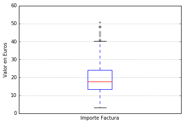

```python
plt.boxplot(importe);
plt.grid(True)

# más opciones sin perder las anteriores --- avanzamos de forma incremental...

plt.xlabel('Importe Factura')
plt.ylabel('Valor en Euros');
plt.xticks([0],['Importe']);
```

```python
# relación entre el día de la semana y el importe factura
np.corr(importe, dia)
```

[output not shown]

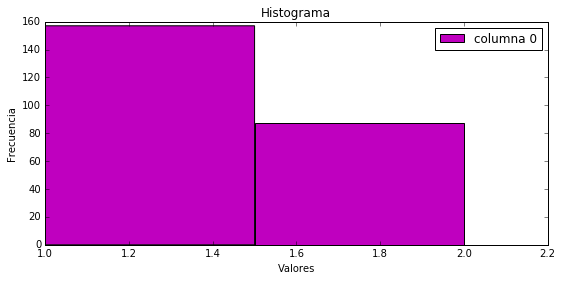

```python
#
sexo = tips[:, 2]

plt.figure(figsize=(9,4))

plt.hist(sexo,
      #   rwidth = 0.9,
         label = ['columna 0'],
         color = ['m'],                        # cada variable de un color
         stacked = True,                            # apiladas
         bins = 2)                                 # 25 barras

plt.legend(loc=0)
plt.title('Histograma')
plt.xlabel('Valores')
plt.ylabel('Frecuencia');
```

```python
dia = tips[:, 4]
dia
```

```
array([ 7.,  7.,  7.,  7.,  7.,  7.,  7.,  7.,  7.,  7.,  7.,  7.,  7.,
        7.,  7.,  7.,  7.,  7.,  7.,  6.,  6.,  6.,  6.,  6.,  6.,  6.,
        6.,  6.,  6.,  6.,  6.,  6.,  6.,  6.,  6.,  6.,  6.,  6.,  6.,
        6.,  6.,  7.,  7.,  7.,  7.,  7.,  7.,  7.,  7.,  7.,  7.,  7.,
        7.,  7.,  7.,  7.,  6.,  6.,  6.,  6.,  6.,  6.,  6.,  6.,  6.,
        6.,  6.,  6.,  6.,  6.,  6.,  6.,  6.,  6.,  6.,  6.,  6.,  4.,
        4.,  4.,  4.,  4.,  4.,  4.,  4.,  4.,  4.,  4.,  4.,  4.,  5.,
        5.,  5.,  5.,  5.,  5.,  5.,  5.,  5.,  5.,  5.,  5.,  6.,  6.,
        6.,  6.,  6.,  6.,  6.,  6.,  6.,  6.,  7.,  7.,  7.,  7.,  7.,
        4.,  4.,  4.,  4.,  4.,  4.,  4.,  4.,  4.,  4.,  4.,  4.,  4.,
        4.,  4.,  4.,  4.,  4.,  4.,  4.,  4.,  4.,  4.,  4.,  4.,  4.,
        4.,  4.,  4.,  4.,  4.,  4.,  4.,  7.,  7.,  7.,  7.,  7.,  7.,
        7.,  7.,  7.,  7.,  7.,  7.,  7.,  7.,  7.,  7.,  7.,  7.,  6.,
        6.,  6.,  6.,  7.,  7.,  7.,  7.,  7.,  7.,  7.,  7.,  7.,  7.,
        7.,  7.,  7.,  7.,  7.,  7.,  7.,  7.,  7.,  4.,  4.,  4.,  4.,
        4.,  4.,  4.,  4.,  4.,  4.,  4.,  4.,  4.,  4.,  4.,  6.,  6.,
        6.,  6.,  6.,  6.,  6.,  6.,  6.,  6.,  6.,  6.,  6.,  6.,  5.,
        5.,  5.,  5.,  5.,  5.,  5.,  6.,  6.,  6.,  6.,  6.,  6.,  6.,
        6.,  6.,  6.,  6.,  6.,  6.,  6.,  6.,  6.,  4.])
```

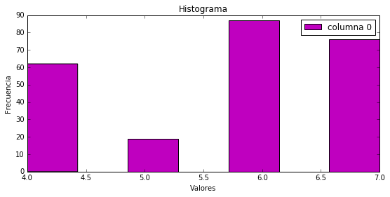

```python
#
dia = tips[:, 4]

plt.figure(figsize=(9,4))

plt.hist(dia,
      #   rwidth = 0.9,
         label = ['columna 0'],
         color = ['m'],                        # cada variable de un color
         stacked = True,                            # apiladas
         bins = 7)                                 # 25 barras

plt.legend(loc=0)
plt.title('Histograma')
plt.xlabel('Valores')
plt.ylabel('Frecuencia');
```

```python
# Sol:
```

- Modifica el valor de los últimos 5 elementos. Su nuevo valor es 30.

```python
# Sol:
```

#### 2 Ejercicio

El archivo de texto holland_temperature.dat recoge datos de las diferentes temperaturas registradas en Holanda en los últimos 12 meses.

a) Calcula la media de las temperaturas.

- Descarga el fichero holland_temperature.dat en tu directorio de trabajo.
- Carga los datos en una array llamado **temperatura** mediante la función **loadtxt**.
- Utiliza la función **mean** para calcular la media.

**Nota**: La media es 10.125.

```python
# Sol
```

b) Nos interesa conocer los meses del año donde la temperatura ha sido superior a la media.

- Crear un array de meses [1,...,12]. Usa la función **arange**.
- Escribir la expresión que devuelve los meses donde la temperatura ha sido superior a la media usando como máscara un array de booleanos.

**Nota**: La solución es: [5, 6, 7, 8, 9, 10]

```python
# Sol:
```

c) Queremos saber qué mes ha estado más cerca de la media.

- Para ello calcula el array de diferencias con respecto a la media (operación diferencia).
- Luego utiliza la función **argmin** de Numpy para calcular el índice del array que contiene el mínimo valor.

**Nota**: la solución es: 'El mes más cercano a los 10.12 grados es el mes 9'

```python
# Sol:
```